# Vecshift Visualization Themes: Accessible and Professional Graphics

Vecshift Package

2025-08-11

# Introduction

The vecshift package provides a comprehensive theme and color system designed specifically for employment data visualization. The system prioritizes accessibility, clean design, and professional appearance while maintaining scientific rigor in color selection.

## Design Philosophy

# Color Palettes

## Main Palette System

The vecshift package provides several carefully designed color palettes:

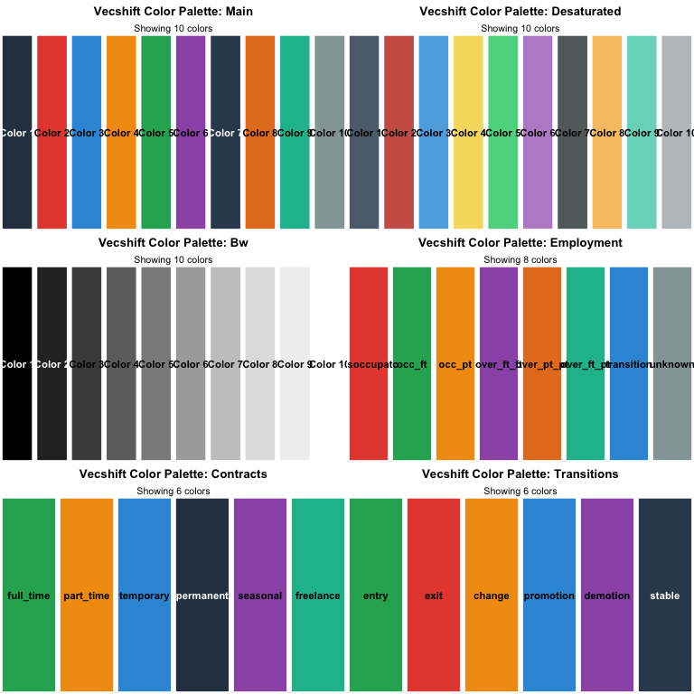

```r
if (has_ggplot2) {
  # Create a grid of palette previews
  library(gridExtra)

  palettes <- c("main", "desaturated", "bw", "employment", "contracts", "transitions")

  plots <- lapply(palettes, function(pal) {
    preview_vecshift_colors(pal, show_hex = FALSE) +
      theme(plot.title = element_text(size = 10),
            plot.subtitle = element_text(size = 8))
  })

  do.call(grid.arrange, c(plots, ncol = 2))
}
```

## Accessing Color Palettes

### Basic Usage

```r
# Get main dark-toned palette
main_colors <- vecshift_colors("main")
print(main_colors[1:5])
```

```
#> [1] "#2C3E50" "#E74C3C" "#3498DB" "#F39C12" "#27AE60"
```

```r
# Get employment-specific colors
emp_colors <- vecshift_colors("employment")
print(emp_colors)
```

```
#> disoccupato      occ_ft      occ_pt  over_ft_ft  over_pt_pt  over_ft_pt
#>   "#E74C3C"   "#27AE60"   "#F39C12"   "#9B59B6"   "#E67E22"   "#1ABC9C"
#>  transition     unknown
#>   "#3498DB"   "#95A5A6"
```

```r
# Get desaturated version
desat_colors <- vecshift_colors("desaturated", n = 5)
print(desat_colors)
```

```
#> [1] "#5D6D7E" "#CD6155" "#5DADE2" "#F7DC6F" "#58D68D"
```

### Advanced Options

```r
# Get colors with transparency
alpha_colors <- vecshift_colors("main", n = 3, alpha = 0.7)
print(alpha_colors)
```

```
#> [1] "#2C3E50B2" "#E74C3CB2" "#3498DBB2"
```

```r
# Reverse color order
reversed_colors <- vecshift_colors("main", n = 4, reverse = TRUE)
print(reversed_colors)
```

```
#> [1] "#F39C12" "#3498DB" "#E74C3C" "#2C3E50"
```

```r
# Black and white for printing
bw_colors <- vecshift_colors("bw", n = 6)
print(bw_colors)
```

```
#> [1] "#000000" "#2C2C2C" "#4A4A4A" "#6E6E6E" "#8C8C8C" "#AAAAAA"
```

# Theme System

## The Vecshift Theme

The `theme_vecshift()` function creates a clean, professional ggplot2 theme optimized for employment data visualization:

```r
# Create sample employment data for demonstration
set.seed(123)
sample_data <- data.table(
  month = rep(1:12, 3),
  employment_status = rep(c("occ_ft", "occ_pt", "disoccupato"), each = 12),
  count = c(
    rnorm(12, 1000, 100),  # Full-time
    rnorm(12, 300, 50),    # Part-time
    rnorm(12, 150, 30)     # Unemployed
  ),
  contract_type = sample(c("permanent", "temporary", "seasonal"), 36, replace = TRUE),
  region = sample(c("North", "Center", "South"), 36, replace = TRUE)
)
```

### Basic Theme Usage

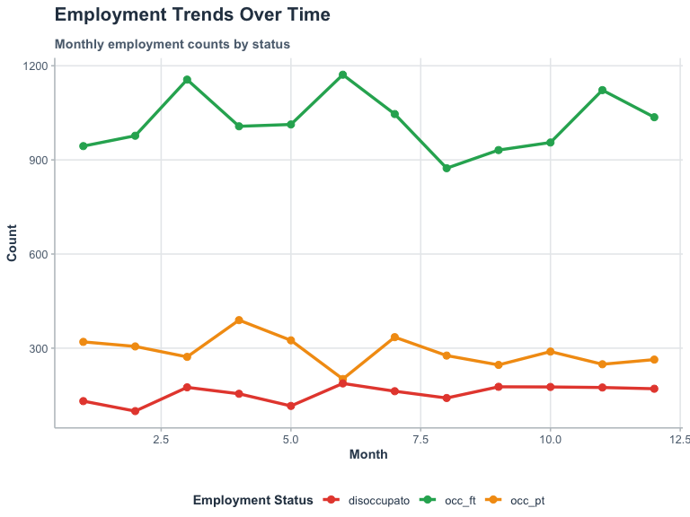

```r
# Basic plot with vecshift theme
ggplot(sample_data, aes(x = month, y = count, color = employment_status)) +
  geom_line(size = 1.2) +
  geom_point(size = 2.5) +
  scale_color_vecshift("employment") +
  labs(
    title = "Employment Trends Over Time",
    subtitle = "Monthly employment counts by status",
    x = "Month",
    y = "Count",
    color = "Employment Status"
  ) +
  theme_vecshift()
```

### Comparing with Default Theme

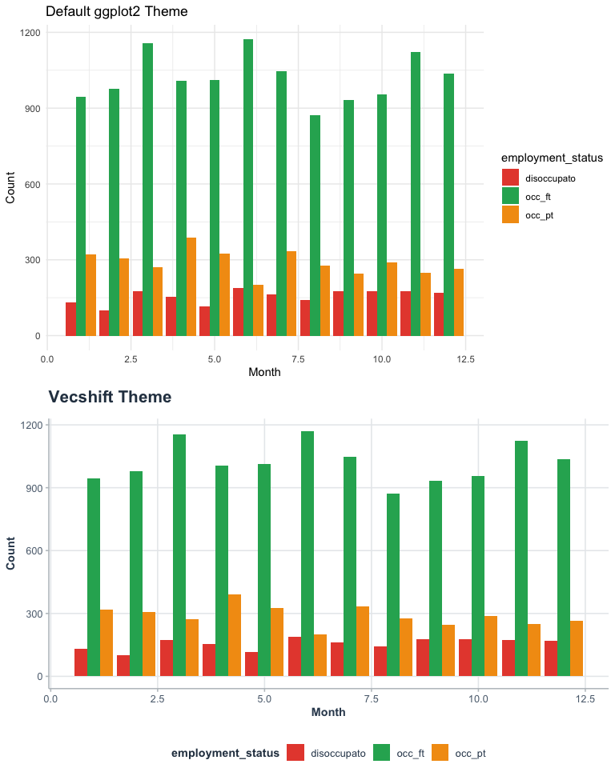

```r
# Same plot with different themes
p1 <- ggplot(sample_data, aes(x = month, y = count, fill = employment_status)) +
  geom_col(position = "dodge") +
  scale_fill_vecshift("employment") +
  labs(title = "Default ggplot2 Theme", x = "Month", y = "Count") +
  theme_minimal()

p2 <- ggplot(sample_data, aes(x = month, y = count, fill = employment_status)) +
  geom_col(position = "dodge") +
  scale_fill_vecshift("employment") +
  labs(title = "Vecshift Theme", x = "Month", y = "Count") +
  theme_vecshift()

grid.arrange(p1, p2, ncol = 1)
```

## Theme Customization

The vecshift theme offers extensive customization options:

### Grid and Axis Options

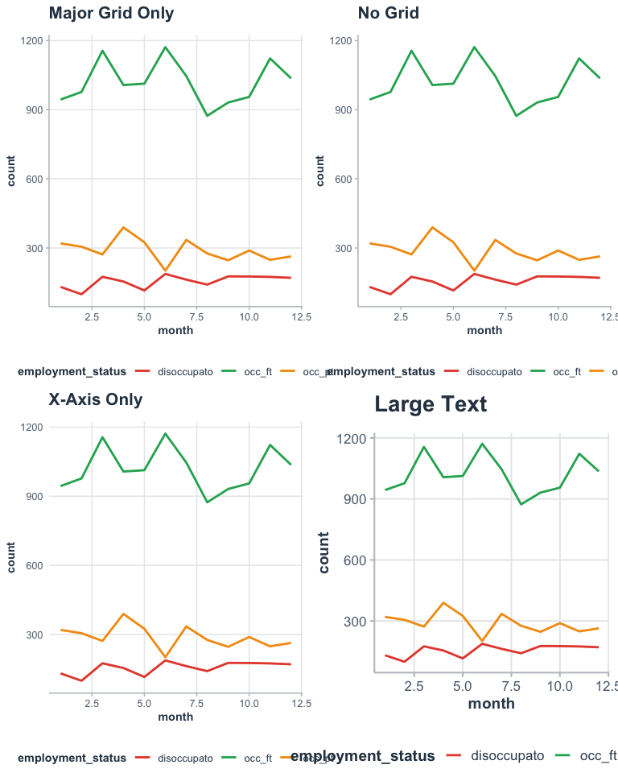

```r
# Different grid options
p1 <- ggplot(sample_data, aes(x = month, y = count)) +
  geom_line(aes(color = employment_status), size = 1) +
  scale_color_vecshift("employment") +
  labs(title = "Major Grid Only") +
  theme_vecshift(grid = "major")

p2 <- ggplot(sample_data, aes(x = month, y = count)) +
  geom_line(aes(color = employment_status), size = 1) +
  scale_color_vecshift("employment") +
  labs(title = "No Grid") +
  theme_vecshift(grid = "none")

p3 <- ggplot(sample_data, aes(x = month, y = count)) +
  geom_line(aes(color = employment_status), size = 1) +
  scale_color_vecshift("employment") +
  labs(title = "X-Axis Only") +
  theme_vecshift(axis = "x", ticks = "x")

p4 <- ggplot(sample_data, aes(x = month, y = count)) +
  geom_line(aes(color = employment_status), size = 1) +
  scale_color_vecshift("employment") +
  labs(title = "Large Text") +
  theme_vecshift(base_size = 16)

grid.arrange(p1, p2, p3, p4, ncol = 2)
```

# Specialized Visualizations for Employment Data

## Employment Status Over Time

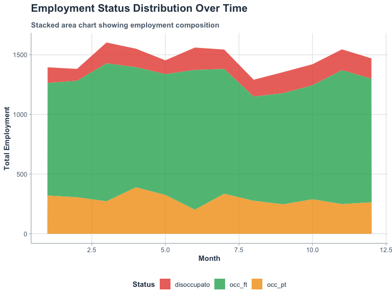

```r
# Create timeline data
timeline_data <- sample_data[, .(total = sum(count)), by = .(month, employment_status)]

ggplot(timeline_data, aes(x = month, y = total, fill = employment_status)) +
  geom_area(position = "stack", alpha = 0.8) +
  scale_fill_vecshift("employment") +
  labs(
    title = "Employment Status Distribution Over Time",
    subtitle = "Stacked area chart showing employment composition",
    x = "Month",
    y = "Total Employment",
    fill = "Status"
  ) +
  theme_vecshift(grid = "major") +
  theme(legend.position = "bottom")
```

## Contract Type Analysis

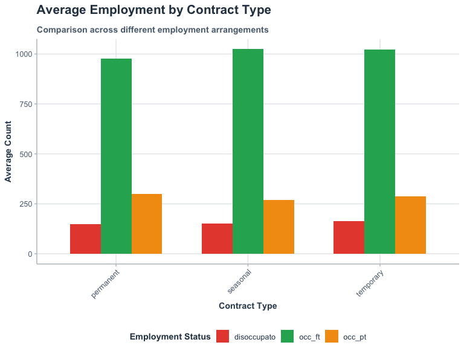

```r
# Fix the aggregation - employment_status is already in the grouping variable
# so we don't need to select it again in the summary
contract_summary <- sample_data[, .(
  avg_count = mean(count)
), by = .(contract_type, employment_status)]

ggplot(contract_summary, aes(x = contract_type, y = avg_count, fill = employment_status)) +
  geom_col(position = "dodge", width = 0.7) +
  scale_fill_vecshift("employment") +
  labs(
    title = "Average Employment by Contract Type",
    subtitle = "Comparison across different employment arrangements",
    x = "Contract Type",
    y = "Average Count",
    fill = "Employment Status"
  ) +
  theme_vecshift(grid = "major", ticks = "both") +
  theme(
    axis.text.x = element_text(angle = 45, hjust = 1),
    legend.position = "bottom"
  )
```

## Regional Distribution

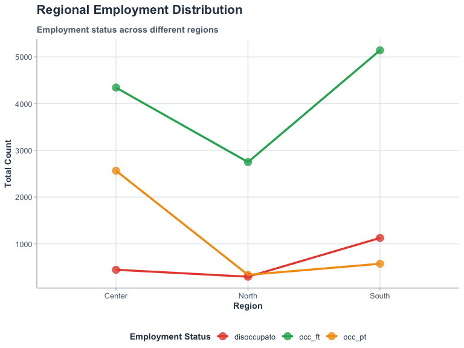

```r
regional_data <- sample_data[, .(total = sum(count)), by = .(region, employment_status)]

ggplot(regional_data, aes(x = region, y = total, color = employment_status)) +
  geom_point(size = 4, alpha = 0.8) +
  geom_line(aes(group = employment_status), size = 1.2) +
  scale_color_vecshift("employment") +
  labs(
    title = "Regional Employment Distribution",
    subtitle = "Employment status across different regions",
    x = "Region",
    y = "Total Count",
    color = "Employment Status"
  ) +
  theme_vecshift(grid = "major") +
  theme(legend.position = "bottom")
```

# Accessibility Features

## Testing Color Accessibility

The vecshift package includes built-in accessibility testing:

```r
# Test accessibility of employment palette
cat("Testing employment palette accessibility:\n")
```

```
#> Testing employment palette accessibility:
```

```r
test_vecshift_accessibility("employment")
```

```
#> Accessibility Test Results for employment palette:
#> Total colors tested: 8
#> WCAG AA compliance: 8 / 8 ( 100 %)
#> WCAG AAA compliance: 5 / 8 ( 62 %)
#> ✓ All colors meet WCAG AA accessibility standards
```

```r
cat("\n\nTesting main palette accessibility:\n")
```

```
#>
#>
#> Testing main palette accessibility:
```

```r
test_vecshift_accessibility("main")
```

```
#> Accessibility Test Results for main palette:
#> Total colors tested: 10
#> WCAG AA compliance: 10 / 10 ( 100 %)
#> WCAG AAA compliance: 7 / 10 ( 70 %)
#> ✓ All colors meet WCAG AA accessibility standards
```

## Alternative Encodings for Accessibility

When color alone isn’t sufficient, use additional visual encodings:

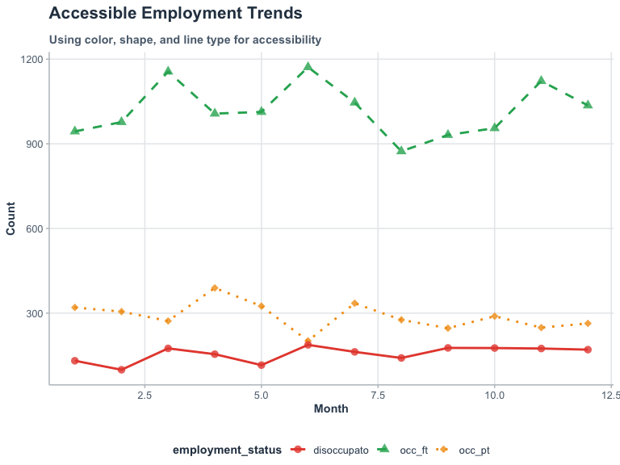

```r
# Using both color and shape for accessibility
ggplot(sample_data, aes(x = month, y = count, color = employment_status, shape = employment_status)) +
  geom_point(size = 3, alpha = 0.8) +
  geom_line(aes(linetype = employment_status), size = 1) +
  scale_color_vecshift("employment") +
  scale_shape_manual(values = c(16, 17, 18)) +
  scale_linetype_manual(values = c("solid", "dashed", "dotted")) +
  labs(
    title = "Accessible Employment Trends",
    subtitle = "Using color, shape, and line type for accessibility",
    x = "Month",
    y = "Count"
  ) +
  theme_vecshift() +
  theme(legend.position = "bottom")
```

## Desaturated and Black & White Versions

For situations where color accessibility is critical or printing requirements:

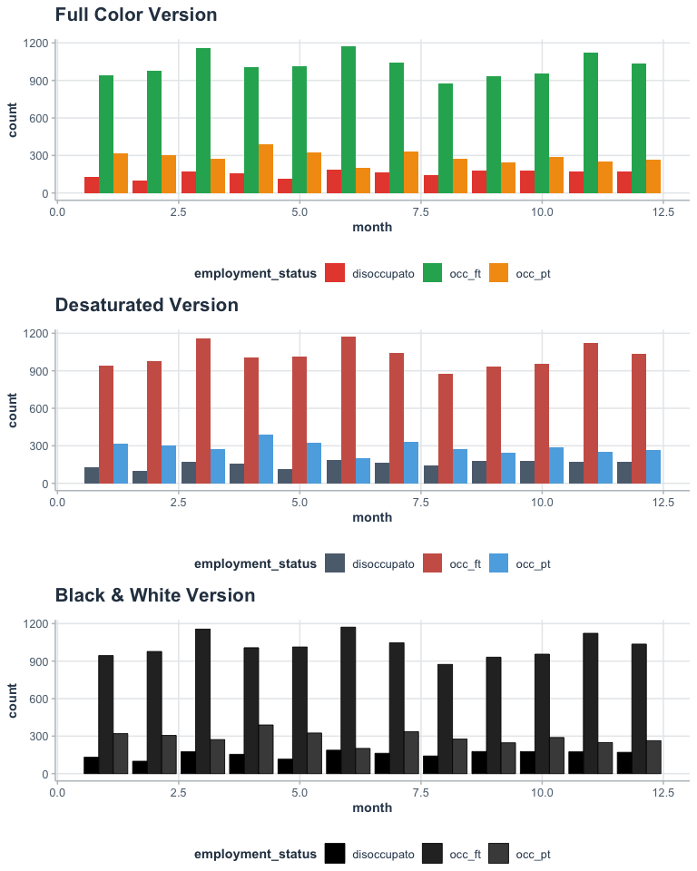

```r
# Original with full colors
p1 <- ggplot(sample_data, aes(x = month, y = count, fill = employment_status)) +
  geom_col(position = "dodge") +
  scale_fill_vecshift("employment") +
  labs(title = "Full Color Version") +
  theme_vecshift()

# Desaturated version
p2 <- ggplot(sample_data, aes(x = month, y = count, fill = employment_status)) +
  geom_col(position = "dodge") +
  scale_fill_vecshift("desaturated") +
  labs(title = "Desaturated Version") +
  theme_vecshift()

# Black and white version
p3 <- ggplot(sample_data, aes(x = month, y = count, fill = employment_status)) +
  geom_col(position = "dodge", color = "black", size = 0.3) +
  scale_fill_vecshift("bw") +
  labs(title = "Black & White Version") +
  theme_vecshift()

grid.arrange(p1, p2, p3, ncol = 1)
```

# Advanced Usage

## Setting Default Theme

You can set the vecshift theme as the default for your R session:

```r
# Set vecshift theme as default
set_vecshift_theme(base_size = 12, grid = "major")

# All subsequent ggplot2 plots will use vecshift theme
# Reset when done
reset_default_theme()
```

## Custom Color Selection

For specialized employment data analysis:

```r
# Get specific employment colors
key_colors <- get_employment_colors(c("occ_ft", "occ_pt", "disoccupato"))
print(key_colors)
```

```
#>      occ_ft      occ_pt disoccupato
#>   "#27AE60"   "#F39C12"   "#E74C3C"
```

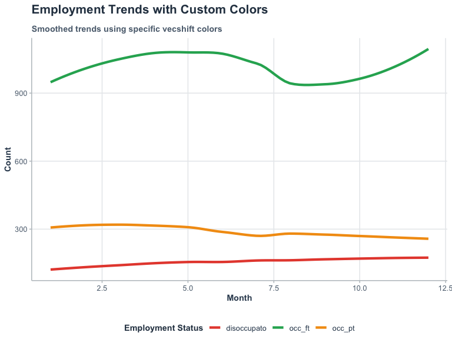

```r
# Use in custom visualization
ggplot(sample_data[employment_status %in% names(key_colors)],
       aes(x = month, y = count, color = employment_status)) +
  geom_smooth(method = "loess", se = FALSE, size = 1.5) +
  scale_color_manual(values = key_colors) +
  labs(
    title = "Employment Trends with Custom Colors",
    subtitle = "Smoothed trends using specific vecshift colors",
    x = "Month",
    y = "Count",
    color = "Employment Status"
  ) +
  theme_vecshift()
```

## Integration with Vecshift Analysis

Combining the theme system with vecshift analysis functions:

```r
# Example workflow (not run due to data requirements)
#
# # Process employment data
# processed_data <- vecshift(employment_records, classify_status = TRUE)
#
# # Analyze patterns
# status_patterns <- analyze_status_patterns(processed_data)
#
# # Visualize with vecshift theme
# ggplot(status_patterns$duration_summary, aes(x = status, y = mean_duration)) +
#   geom_col(aes(fill = status)) +
#   scale_fill_vecshift("employment") +
#   theme_vecshift() +
#   labs(title = "Average Duration by Employment Status")
```

# Best Practices

## When to Use Each Palette

- **Main**: General purpose, presentations, digital displays
- **Desaturated**: Subtle distinctions, overlaid data, secondary information
- **Black & White**: Printing, publications with color restrictions
- **Employment**: Specifically for employment status data from vecshift
- **Contracts**: For contract type analysis
- **Transitions**: For temporal change analysis

## Color Usage Guidelines

1. **Limit Colors**: Use no more than 7-8 distinct colors in a single plot
2. **Semantic Consistency**: Keep employment status colors consistent across plots
3. **Test Accessibility**: Use `test_vecshift_accessibility()` for important visualizations
4. **Provide Alternatives**: Use shape, pattern, or text when color is critical
5. **Consider Context**: Choose palette variants based on intended use

## Typography and Layout

- Use consistent font sizes across related plots
- Keep titles informative but concise
- Place legends at the bottom for better readability
- Use appropriate white space and margins

# Conclusion

The vecshift theme system provides a comprehensive solution for creating accessible, professional employment data visualizations. By combining scientifically-backed color palettes with clean design principles, it ensures that your employment analyses are both beautiful and accessible to all users.

For more information about the vecshift package and its analytical capabilities, see the other package vignettes and documentation.